**Vaidehi Patole**  
**Probability Theory and Introductory to Statistics**  
**M1 Project Report**  
**ALY6010 - 70487**  
**Northeastern University**  
**Dr. Dee Chiluiza, PhD**  
11 November, 2021

**INTRODUCTION**

**Global car sales Market**  
Data release by International car market represent that after COVID it has been observed that sales of car rose drastically all around the globe. In Countries like China, India and USA it has been clearly seen increase in the sales of cars. Especially in India car sales rose drastically in the first half of 2021 and increased phenomenal by the second half of 2021. In addition, it has been clearly seen that china is market has recovered from 2020 losses sales were 27% high as compared to 2019. Moreover, data also depicts that in the USA despite having COVID restriction economy recovered very fast in the first six months of 2021 and sales increased by 29% in first six months of 2021.On the other hand, countries like Japan, brazil and in some parts of the Europe they are still recovering from damage caused by COVID.  
**Car sales market in India**  
In India brands like Maruti Suzuki, Toyota, Mahindra and Hyundai has a biggest market including and luxury car manufacturers, such as BMW, Audi, and JLR. In the previous three years, the organized sales channel has seen substantial expansion. Increased sales of used automobiles in metro cities, as well as a surge in online sales platforms like CarDekho, Cars24, and Droom, are driving this growth.  
**Importance of discrete and continuous probability**  
The definition of a random variable is a variable that can hold a variety of values based on the outcome of a random operation. However, it is unable to express the chance of receiving those various values. As a result, in any random process, probability distribution aids in the creation of a clear image of all the possible values and their respective likelihood of occurrence.

```r
library(readxl)
data = read_excel("d:\\Users\\Admin\\Downloads\\car_sales_india.xlsx")
```

**Task 1**

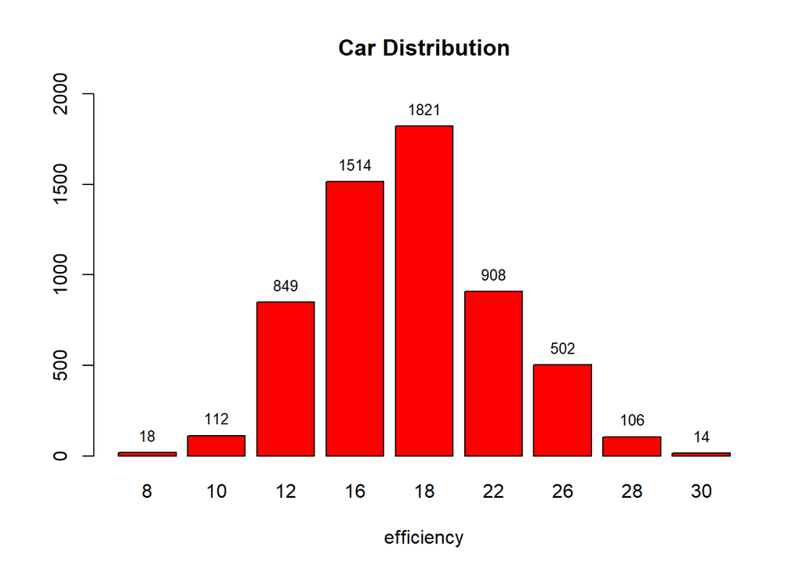

```r
counts <- table(data$Efficiency)
#counts
bar1=barplot(counts, main="Car Distribution",xlab="efficiency", col="red", ylim= c(0,2000))
text(y=counts,bar1,counts, cex=0.8, pos = 3)
```

**Task 2**

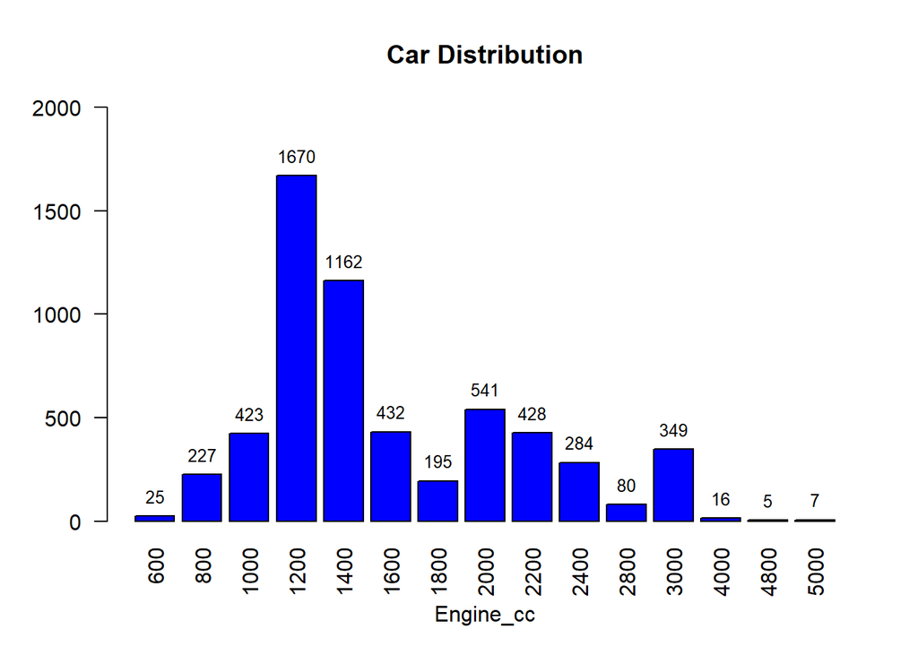

```r
counts <- table(data$Engine_cc)
#counts
bar2 = barplot(counts, main="Car Distribution",xlab="Engine_cc", col="blue",ylim= c(0,2000), las=2)
text(y=counts,bar2,counts, cex=0.8, pos = 3)
```

**Observation 2:**

This bar plot represents Engine cc number 1200 has the highest Enginee_cc that is of 1670 and lowest counts are 16,5,7.

**Task 3**

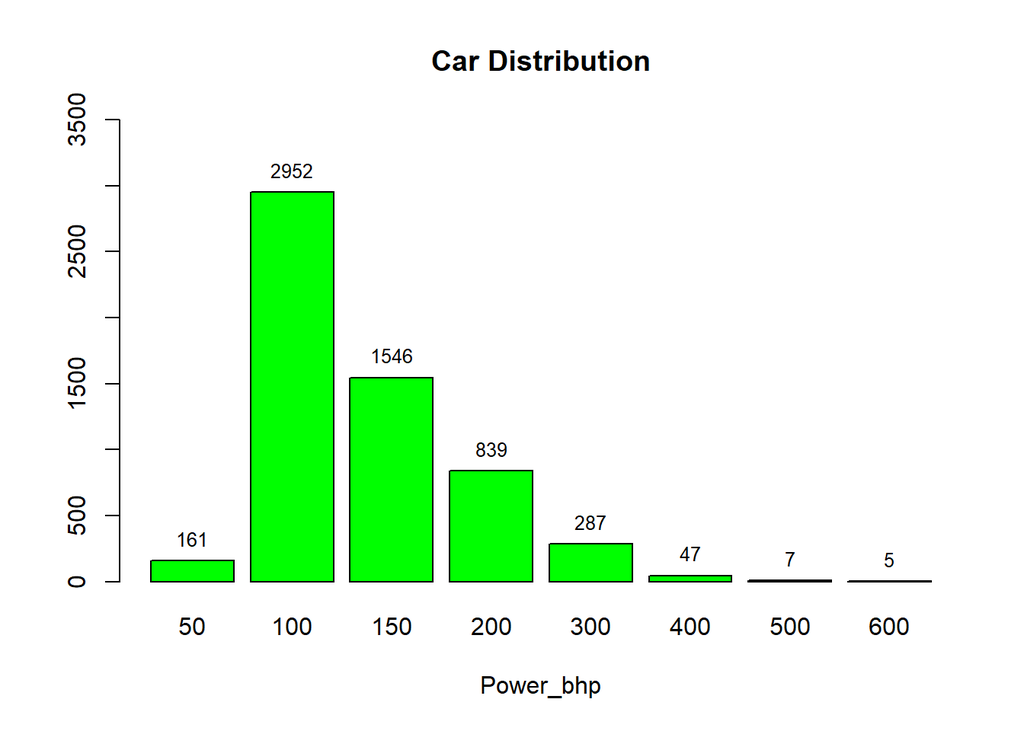

```r
counts <- table(data$Power_bhp)
#counts
bar3 = barplot(counts, main="Car Distribution",xlab="Power_bhp", col="green",ylim= c(0,3500) )
text(y=counts,bar3,counts, cex=0.8, pos = 3)
```

**Task 4**

```r
counts <- table(data$Seats)
counts
```

```
##
##    2    4    5    6    8   10
##   13   99 4891  701  133    7
```

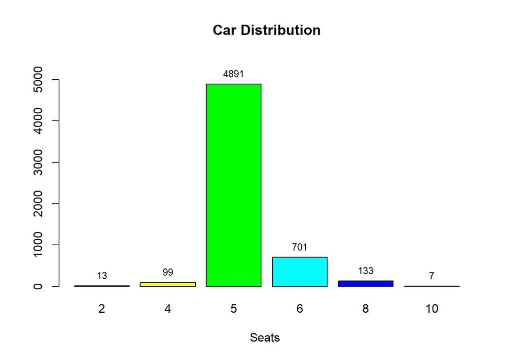

```r
bar4 = barplot(counts, main="Car Distribution",xlab="Seats ", col=rainbow(6) ,ylim = c(0,5500) )
text(y=counts,bar4,counts, cex=0.8, pos = 3)
```

**Observation 4:**  
In the above bar plot of it is clear that number 5 has the more seats than the other seats and number 5 is the median of the graph.

**Task 5**

```r
ef1 = as.data.frame(table(data$Efficiency))

ef2 = data.frame(ef1$Var1, ef1$Freq)

ef3 = rename(ef2, Efficiency =
ef1.Var1, Frequency = ef1.Freq)

ef4 = ef3%>%
  select(Efficiency, Frequency)%>%
  mutate(Prob = round(Frequency/sum(Frequency),3))
 knitr::kable(ef4)
```

| Efficiency | Frequency | Prob |
| --- | --- | --- |
| 8 | 18 | 0.003 |
| 10 | 112 | 0.019 |
| 12 | 849 | 0.145 |
| 16 | 1514 | 0.259 |
| 18 | 1821 | 0.312 |
| 22 | 908 | 0.155 |
| 26 | 502 | 0.086 |
| 28 | 106 | 0.018 |
| 30 | 14 | 0.002 |

**Task 6**

```r
ecc1 = as.data.frame(table(data$Engine_cc))

ecc2 = data.frame(ecc1$Var1, ecc1$Freq)

ecc3 = rename(ecc2, Engine_cc = ecc1.Var1, Frequency = ecc1.Freq)

ecc4 = ecc3%>%
  select(Engine_cc, Frequency)%>%
  mutate(Prob = round(Frequency/sum(Frequency),3))


knitr::kable(ecc4)
```

| Engine_cc | Frequency | Prob |
| --- | --- | --- |
| 600 | 25 | 0.004 |
| 800 | 227 | 0.039 |
| 1000 | 423 | 0.072 |
| 1200 | 1670 | 0.286 |
| 1400 | 1162 | 0.199 |
| 1600 | 432 | 0.074 |
| 1800 | 195 | 0.033 |
| 2000 | 541 | 0.093 |
| 2200 | 428 | 0.073 |
| 2400 | 284 | 0.049 |
| 2800 | 80 | 0.014 |
| 3000 | 349 | 0.060 |
| 4000 | 16 | 0.003 |
| 4800 | 5 | 0.001 |
| 5000 | 7 | 0.001 |

**Task 7**

```r
bph1 = as.data.frame(table(data$Power_bhp))

bph2 = data.frame(bph1$Var1, bph1$Freq)

bph3 = rename(bph2,  Power_bhp= bph1.Var1, Frequency = bph1.Freq)

bph4 = bph3%>%
  select(Power_bhp, Frequency)%>%
  mutate(Prob = round(Frequency/sum(Frequency),3))
 knitr::kable(bph4)
```

| Power_bhp | Frequency | Prob |
| --- | --- | --- |
| 50 | 161 | 0.028 |
| 100 | 2952 | 0.505 |
| 150 | 1546 | 0.265 |
| 200 | 839 | 0.144 |
| 300 | 287 | 0.049 |
| 400 | 47 | 0.008 |
| 500 | 7 | 0.001 |
| 600 | 5 | 0.001 |

**Task 8**

```r
s1 = as.data.frame(table(data$Seats))

s2 = data.frame(s1$Var1, s1$Freq)

s3 = rename(s2,  Seats= s1.Var1, Frequency = s1.Freq)

s4 = s3%>%
  select(Seats, Frequency)%>%
  mutate(Prob = round(Frequency/sum(Frequency),3))
  knitr::kable(s4)
```

| Seats | Frequency | Prob |
| --- | --- | --- |
| 2 | 13 | 0.002 |
| 4 | 99 | 0.017 |
| 5 | 4891 | 0.837 |
| 6 | 701 | 0.120 |
| 8 | 133 | 0.023 |
| 10 | 7 | 0.001 |

**Task 9**

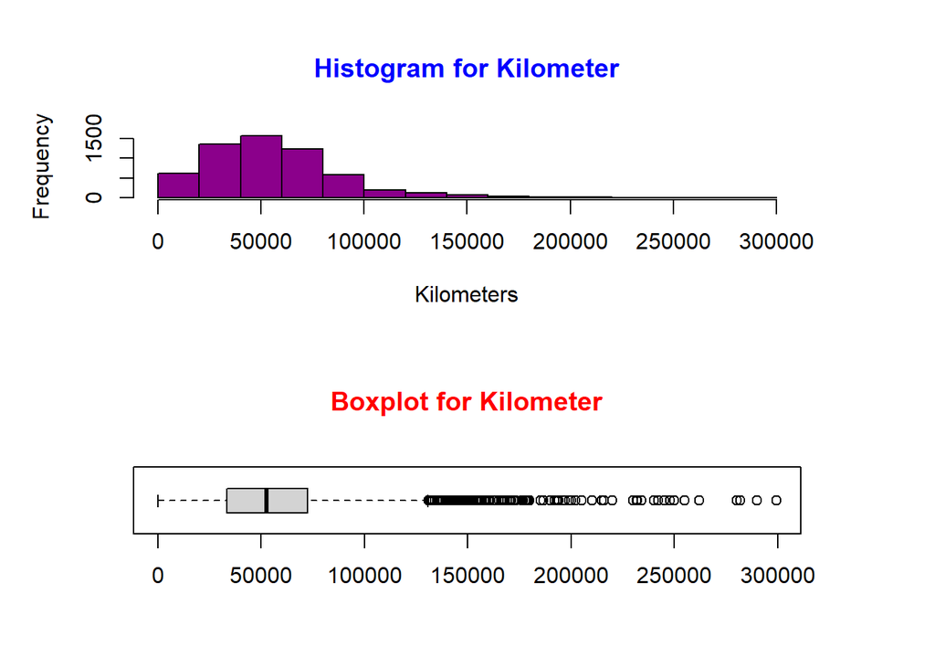

```r
par(mfrow = c(2,1),mai = c (1,1,1,1))
hist(data$Km,
main="Histogram for Kilometer", col.main ="Blue",
xlab="Kilometers",
col="darkmagenta"
)
boxplot(data$Km, main="Boxplot for Kilometer", col.main = "Red",
        horizontal = TRUE
  )
```

**Task 10**

```r
par(mfrow = c(2,1),mai = c (1,1,1,1))
hist(data$Price,
main="Histogram for Price", col.main ="Blue",
xlab="Price",
col="chocolate",

)

summary(data$Price)
```

```
##    Min. 1st Qu.  Median    Mean 3rd Qu.    Max.
##     618    4938    8009   13286   14039   99663
```

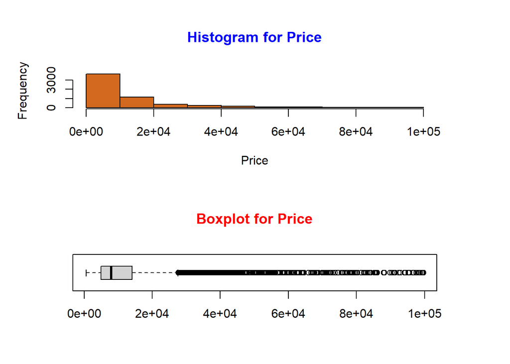

```r
boxplot(data$Price, main="Boxplot for Price", col.main = "Red",
        horizontal = TRUE
  )
```

**Conclusion:**  
In this project 1 first step was to take dataset in R and read that data after that data analysis is done on the cars sales in India using different types of the graphs used like bar plots, histogram and boxplot to shows different car information regarding engine_cc, Efficiency, Power, price and kilometre.

**Bibliography:**  
1.Statista, Welcome, North-eastern University, Published by Mathilda Carlier, Nov 10,2021 https://www.statista.com/topics/1487/automotive-industry/#dossierKeyfigures

2.India used car market -Growths ,Trends, Covid-19 impact and Forecasts(2021-2026) ,https://www.mordorintelligence.com/industry-reports/india-used-car-market

3.Probability distribution discrete and continuous, Published by Semma Singh ,April3,2019 https://medium.com/@seema.singh/probability-distributions-discrete-and-continuous-7a94ede66dc0

**Appendix**  
1.car_sales_india.xlsx  
2.Project1_Vaidehi.Rmd